# Methods 2 – Portfolio Assignment 1

- *Type:* Group assignment
- *Due:* 10 March 2024, 23:59

```r
pacman::p_load(ggplot2, tidyverse)
```

In the following exercises, you will be asked to generate and summarize simulations from statistical models. You should use what you have learned so far (i.e. for loop, if else statements, sampling from continuous and discrete distributions…) to generate observations and summarize your samples using (one of) the appropriate methods. You can find examples of how to do that in Ch. 5. Note that here we will only focus on generative models, several aspects for inference and hypothesis testing discussed in Ch. 4 are not directly needed in this context.

In the first exercise, we will assume that the population of interest has a proportion of 0.51 men and 0.49 women. Your model should reflect that.

Please submit your answers on GitHub Classroom.

1. *(5.2 from ROS)* **Continuous probability simulation:** The logarithms of weights (in pounds) of men in the United States are approximately normally distributed with mean 5.13 and standard deviation 0.17; women’s log weights are approximately normally distributed with mean 4.96 and standard deviation 0.20. Suppose 10 adults selected at random step on an elevator with a capacity of 1750 pounds. What is the probability that their total weight exceeds this limit?

The following code and text is written by Johannes:

```r
set.seed(111)   # Setting seed

# Defining info from description
prop_female <- .49  # Probability of random person being a female
men_weight <- 5.13 # Mean logarithmic weight of men
men_sd <- .17   # Standard deviation in logarithmic weight of men
women_weight <- 4.96    #Mean logarithmic weight of women
women_sd <- .20 #Standard deviation in logarithmic weight of women

# Setting number of people, capacity of elevator, number of simulations
n <- 10
capacity <- 1750
num_sims <- 100000

Above_capacity <- rep(NA, num_sims)

for (j in 1:num_sims) { # runs the simulation for the specified number of times.
  weights <- rep(NA, n)
  is_female <- rbinom(n=n, size=1, prob=prop_female)
  for (i in 1:n) {  # generates random weights for each adult based on their gender, and calculates the total weight.
    log_weight <- ifelse(is_female[i]==1,   # Assigning gender
                         rnorm(n=1, mean=women_weight, sd=women_sd),    # Drawing from normal distribution
                         rnorm(n=1, mean=men_weight, sd=men_sd) # -||-
                         )
    weights[i]<- exp(log_weight)    # Inverting the logarithmic value, getting weight in pounds
  }
  Above_capacity[j] <- ifelse(capacity<sum(weights), 1, 0)  # Checking if sum of weights for simulations draws is above capacity
}
sum(Above_capacity) / num_sims # Probability that the weight of 10 people is above capacity of elevator
```

```
## [1] 0.05697
```

## The probability that the weight of 10 random people exceed the elevator’s capacity limit of 1750 pounds is approximately 5,7%.

2. *(5.6 from ROS)* **Propagation of uncertainty:** We use a highly idealized setting to illustrate the use of simulations in combining uncertainties. Suppose a company changes its technology for widget production, and a study estimates the cost savings at $5 per unit, but with a standard error of $4. Furthermore, a forecast estimates the size of the market (that is, the number of widgets that will be sold) at 40 000, with a standard error of 10 000. Assuming these two sources of uncertainty are independent, use simulation to estimate the total amount of money saved by the new product (that is, savings per unit, multiplied by size of the market).

The following code and text is written by Sofia:

```r
# Setting seed
set.seed(1999)

# Defining variables market, savings and the vector money saved
market <- 0
savings <- 0
money_saved <- c()

for (i in 1:100000){ # Running simulation 100.000 times
  market <- rnorm(1, 40000, 10000) # Setting estimates from forecast's estimate of market size
  savings <- rnorm(1, 5, 4) # Setting estimates from study's estimated cost savings
  money_saved <- c(money_saved, market * savings) # Multiplying market size and savings per product to get total amount of money saved
}

mean(money_saved) # Calculating our simulation's estimation of total savings
```

```
## [1] 200627.8
```

## Given the estimated savings per product and market size, our simulation estimates the company’s total savings of the new produc to be approximately $200628.

3. *(5.10 from ROS)* **Inference for a ratio of parameters:** A (hypothetical) study compares the costs and effectiveness of two different medical treatments.
   - In the first part of the study, the difference in costs between treatments A and B is estimated at $600 per patient, with a standard error of $400, based on a regression with 50 degrees of freedom
   - In the second part of the study, the difference in effectiveness is estimated at 3.0 (on some relevant measure), with a standard error of 1.0, based on a regression with 100 degrees of freedom.
   - For simplicity, assume that the data from the two parts of the study were collected independently Inference is desired for the incremental cost-effectiveness ratio: the difference between the average costs of the two treatments, divided by the difference between their average effectiveness, a problem discussed further by Heitjan, Moskowitz, and Whang (1999).

The following code and text is written by Sissel

1. Create 1000 simulation draws of the cost difference and the effectiveness difference, and make a scatterplot of these draws.

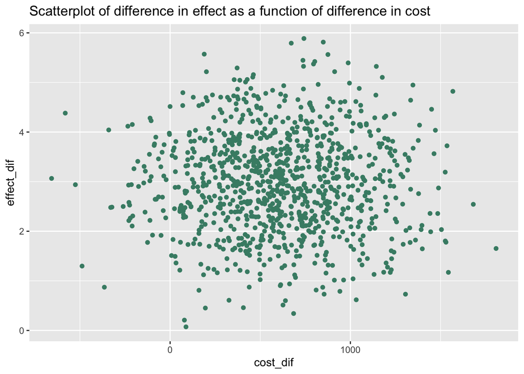

```r
# Setting seed
set.seed(1999)

# Defining info from description
mean_cd <- 600
sd_cd <- 400
mean_ed <- 3
sd_ed <- 1

# Defining degrees of freedom
df_cost <- 50
df_effect <- 100

cost_dif <- rnorm(1000, mean_cd, sd_cd) * sqrt((df_cost -2)/df_cost)# Creating 1000 simulation draws of cost difference while adjusting for t-distribution approximation
effect_dif <- rnorm(1000, mean_ed, sd_ed) * sqrt((df_effect -2)/df_effect) # Same for effectiveness difference

df_med_dif <- data.frame(cost_dif, effect_dif) # Creating dataframe

ggplot(df_med_dif, # Creating plot and choosing data
       aes(x = cost_dif, y = effect_dif)) + # Choosing variables for x-axis and y-axis
 geom_point (color = "aquamarine4") + # Creating scatterplot
 labs(title = "Scatterplot of difference in effect as a function of difference in cost") #Choosing title
```

(b) Use simulation to come up with an estimate, 50% interval, and 95% interval for the incremental cost-effectiveness ratio.

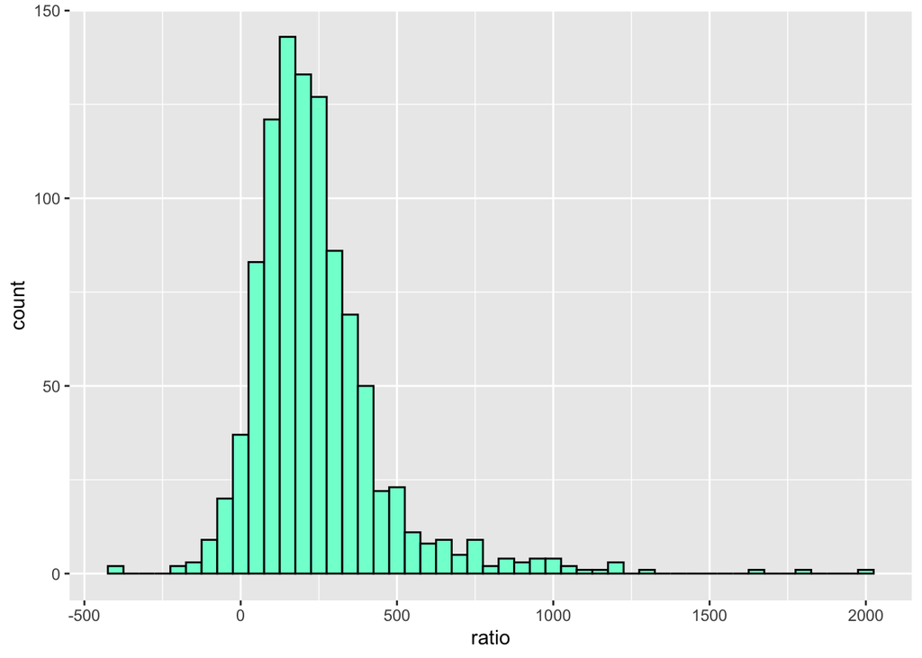

```r
df_med_dif$ratio <- df_med_dif$cost_dif/df_med_dif$effect_dif # Creating column for incremental cost-effectiveness ratio

df_med_dif %>% ggplot(aes(x=ratio)) + # Plotting data
  geom_histogram(binwidth=50, color = "black", fill ="aquamarine") # Creating histogram
```

```r
quantile(df_med_dif$ratio, c(.25, .75)) # Calculating 50% interval
```

```
##      25%      75%
## 110.8537 315.4935
```

```r
quantile(df_med_dif$ratio, c(.025, .975)) # Calculating 95% interval
```

```
##      2.5%     97.5%
## -50.40147 846.16337
```

```r
median(df_med_dif$ratio) # Calculating median
```

```
## [1] 205.331
```

```r
mean(df_med_dif$ratio) # Calculating mean
```

```
## [1] 241.0208
```

```r
mad(df_med_dif$ratio) # Calculating MAD
```

```
## [1] 151.0656
```

The folowing code and text is written by Sofia

## (c) Repeat, changing the standard error on the difference in effectiveness to 2.0.

```r
# Setting seeed
set.seed(111)
#New SD value
effect_dif_sd <- rnorm(1000, 3, 2) * sqrt((df_effect -2)/df_effect) # Defining effectiveness difference estimates and adjusting for t-distribution approximation

df_med_dif_sd <- data.frame(cost_dif, effect_dif_sd) # Creating dataframe

df_med_dif_sd$ratio <- df_med_dif_sd$cost_dif/df_med_dif_sd$effect_dif_sd # Calculating ratio

quantile(df_med_dif_sd$ratio, c(.25, .75))  # Calculating 50% interval
```

```
##       25%       75%
##  85.86604 325.83339
```

```r
quantile(df_med_dif_sd$ratio, c(.025, .975)) # Calculating 95% interval
```

```
##      2.5%     97.5%
## -1336.072  1381.553
```

```r
median(df_med_dif_sd$ratio) # Calculating median
```

```
## [1] 174.2638
```

```r
mean(df_med_dif_sd$ratio) # Calculating mean
```

```
## [1] -181.3832
```

```r
mad(df_med_dif$ratio)
```

```
## [1] 151.0656
```